# Shopping_Trends

➡Importing Libraries

```python
import numpy as np
import pandas as pd
import matplotlib.pyplot as plt
import seaborn as sns
import warnings
warnings.filterwarnings("ignore")
print('All libraries loaded sucessfully...!')
```

```
All libraries loaded sucessfully...!
```

➡Loading a CSV file in our dataframe(df)

```python
df = pd.read_csv("C:/Users/OCS/Downloads/shopping_trends.csv")
```

➡To check total number of rows and columns

```python
df.shape
```

```
(3900, 19)
```

➡To show the top 5 rows of our data

```python
df.head()
```

|  | Customer ID | Age | Gender | Item Purchased | Category | Purchase Amount (USD) | Location | Size | Color | Season | Review Rating | Subscription Status | Payment Method | Shipping Type | Discount Applied | Promo Code Used | Previous Purchases | Preferred Payment Method | Frequency of Purchases |
| --- | --- | --- | --- | --- | --- | --- | --- | --- | --- | --- | --- | --- | --- | --- | --- | --- | --- | --- | --- |
| 0 | 1 | 55 | Male | Blouse | Clothing | 53 | Kentucky | L | Gray | Winter | 3.1 | Yes | Credit Card | Express | Yes | Yes | 14 | Venmo | Fortnightly |
| 1 | 2 | 19 | Male | Sweater | Clothing | 64 | Maine | L | Maroon | Winter | 3.1 | Yes | Bank Transfer | Express | Yes | Yes | 2 | Cash | Fortnightly |
| 2 | 3 | 50 | Male | Jeans | Clothing | 73 | Massachusetts | S | Maroon | Spring | 3.1 | Yes | Cash | Free Shipping | Yes | Yes | 23 | Credit Card | Weekly |
| 3 | 4 | 21 | Male | Sandals | Footwear | 90 | Rhode Island | M | Maroon | Spring | 3.5 | Yes | PayPal | Next Day Air | Yes | Yes | 49 | PayPal | Weekly |
| 4 | 5 | 45 | Male | Blouse | Clothing | 49 | Oregon | M | Turquoise | Spring | 2.7 | Yes | Cash | Free Shipping | Yes | Yes | 31 | PayPal | Annually |

➡To show the bottom 5 rows of our data

```python
df.tail()
```

|  | Customer ID | Age | Gender | Item Purchased | Category | Purchase Amount (USD) | Location | Size | Color | Season | Review Rating | Subscription Status | Payment Method | Shipping Type | Discount Applied | Promo Code Used | Previous Purchases | Preferred Payment Method | Frequency of Purchases |
| --- | --- | --- | --- | --- | --- | --- | --- | --- | --- | --- | --- | --- | --- | --- | --- | --- | --- | --- | --- |
| 3895 | 3896 | 40 | Female | Hoodie | Clothing | 28 | Virginia | L | Turquoise | Summer | 4.2 | No | Cash | 2-Day Shipping | No | No | 32 | Venmo | Weekly |
| 3896 | 3897 | 52 | Female | Backpack | Accessories | 49 | Iowa | L | White | Spring | 4.5 | No | PayPal | Store Pickup | No | No | 41 | Bank Transfer | Bi-Weekly |
| 3897 | 3898 | 46 | Female | Belt | Accessories | 33 | New Jersey | L | Green | Spring | 2.9 | No | Credit Card | Standard | No | No | 24 | Venmo | Quarterly |
| 3898 | 3899 | 44 | Female | Shoes | Footwear | 77 | Minnesota | S | Brown | Summer | 3.8 | No | PayPal | Express | No | No | 24 | Venmo | Weekly |
| 3899 | 3900 | 52 | Female | Handbag | Accessories | 81 | California | M | Beige | Spring | 3.1 | No | Bank Transfer | Store Pickup | No | No | 33 | Venmo | Quarterly |

➡DATA CLEANING🔄

Step 1 - Showing all the rows,columns,data_type to see that there is no null values present in our dataset

```python
df.info()
```

```
<class 'pandas.core.frame.DataFrame'>
RangeIndex: 3900 entries, 0 to 3899
Data columns (total 19 columns):
 #   Column                    Non-Null Count  Dtype
---  ------                    --------------  -----
 0   Customer ID               3900 non-null   int64
 1   Age                       3900 non-null   int64
 2   Gender                    3900 non-null   object
 3   Item Purchased            3900 non-null   object
 4   Category                  3900 non-null   object
 5   Purchase Amount (USD)     3900 non-null   int64
 6   Location                  3900 non-null   object
 7   Size                      3900 non-null   object
 8   Color                     3900 non-null   object
 9   Season                    3900 non-null   object
 10  Review Rating             3900 non-null   float64
 11  Subscription Status       3900 non-null   object
 12  Payment Method            3900 non-null   object
 13  Shipping Type             3900 non-null   object
 14  Discount Applied          3900 non-null   object
 15  Promo Code Used           3900 non-null   object
 16  Previous Purchases        3900 non-null   int64
 17  Preferred Payment Method  3900 non-null   object
 18  Frequency of Purchases    3900 non-null   object
dtypes: float64(1), int64(4), object(14)
memory usage: 579.0+ KB
```

Step 2(a)- To check Null values in the form of 'True' or 'False'

```python
pd.isnull(df)
```

|  | Customer ID | Age | Gender | Item Purchased | Category | Purchase Amount (USD) | Location | Size | Color | Season | Review Rating | Subscription Status | Payment Method | Shipping Type | Discount Applied | Promo Code Used | Previous Purchases | Preferred Payment Method | Frequency of Purchases |
| --- | --- | --- | --- | --- | --- | --- | --- | --- | --- | --- | --- | --- | --- | --- | --- | --- | --- | --- | --- |
| 0 | False | False | False | False | False | False | False | False | False | False | False | False | False | False | False | False | False | False | False |
| 1 | False | False | False | False | False | False | False | False | False | False | False | False | False | False | False | False | False | False | False |
| 2 | False | False | False | False | False | False | False | False | False | False | False | False | False | False | False | False | False | False | False |
| 3 | False | False | False | False | False | False | False | False | False | False | False | False | False | False | False | False | False | False | False |
| 4 | False | False | False | False | False | False | False | False | False | False | False | False | False | False | False | False | False | False | False |
| ... | ... | ... | ... | ... | ... | ... | ... | ... | ... | ... | ... | ... | ... | ... | ... | ... | ... | ... | ... |
| 3895 | False | False | False | False | False | False | False | False | False | False | False | False | False | False | False | False | False | False | False |
| 3896 | False | False | False | False | False | False | False | False | False | False | False | False | False | False | False | False | False | False | False |
| 3897 | False | False | False | False | False | False | False | False | False | False | False | False | False | False | False | False | False | False | False |
| 3898 | False | False | False | False | False | False | False | False | False | False | False | False | False | False | False | False | False | False | False |
| 3899 | False | False | False | False | False | False | False | False | False | False | False | False | False | False | False | False | False | False | False |

3900 rows × 19 columns

(b)- To check Null values in the form of sum of all the values

```python
pd.isnull(df).sum()
```

```
Customer ID                 0
Age                         0
Gender                      0
Item Purchased              0
Category                    0
Purchase Amount (USD)       0
Location                    0
Size                        0
Color                       0
Season                      0
Review Rating               0
Subscription Status         0
Payment Method              0
Shipping Type               0
Discount Applied            0
Promo Code Used             0
Previous Purchases          0
Preferred Payment Method    0
Frequency of Purchases      0
dtype: int64
```

➡To see all the columns

```python
df.columns
```

```
Index(['Customer ID', 'Age', 'Gender', 'Item Purchased', 'Category',
       'Purchase Amount (USD)', 'Location', 'Size', 'Color', 'Season',
       'Review Rating', 'Subscription Status', 'Payment Method',
       'Shipping Type', 'Discount Applied', 'Promo Code Used',
       'Previous Purchases', 'Preferred Payment Method',
       'Frequency of Purchases'],
      dtype='object')
```

➡This method returns description of the data in the DataFrame (i.e. count, mean, std, etc)

```python
df.describe()
```

|  | Customer ID | Age | Purchase Amount (USD) | Review Rating | Previous Purchases |
| --- | --- | --- | --- | --- | --- |
| count | 3900.000000 | 3900.000000 | 3900.000000 | 3900.000000 | 3900.000000 |
| mean | 1950.500000 | 44.068462 | 59.764359 | 3.749949 | 25.351538 |
| std | 1125.977353 | 15.207589 | 23.685392 | 0.716223 | 14.447125 |
| min | 1.000000 | 18.000000 | 20.000000 | 2.500000 | 1.000000 |
| 25% | 975.750000 | 31.000000 | 39.000000 | 3.100000 | 13.000000 |
| 50% | 1950.500000 | 44.000000 | 60.000000 | 3.700000 | 25.000000 |
| 75% | 2925.250000 | 57.000000 | 81.000000 | 4.400000 | 38.000000 |
| max | 3900.000000 | 70.000000 | 100.000000 | 5.000000 | 50.000000 |

▶ EXPLORATORY DATA ANALYSIS

Step 3 - To find Unique values in each columns

```python
for col in df.describe(include="object"):
    print(col)
    print(df[col].unique())
```

```
Gender
['Male' 'Female']
Item Purchased
['Blouse' 'Sweater' 'Jeans' 'Sandals' 'Sneakers' 'Shirt' 'Shorts' 'Coat'
 'Handbag' 'Shoes' 'Dress' 'Skirt' 'Sunglasses' 'Pants' 'Jacket' 'Hoodie'
 'Jewelry' 'T-shirt' 'Scarf' 'Hat' 'Socks' 'Backpack' 'Belt' 'Boots'
 'Gloves']
Category
['Clothing' 'Footwear' 'Outerwear' 'Accessories']
Location
['Kentucky' 'Maine' 'Massachusetts' 'Rhode Island' 'Oregon' 'Wyoming'
 'Montana' 'Louisiana' 'West Virginia' 'Missouri' 'Arkansas' 'Hawaii'
 'Delaware' 'New Hampshire' 'New York' 'Alabama' 'Mississippi'
 'North Carolina' 'California' 'Oklahoma' 'Florida' 'Texas' 'Nevada'
 'Kansas' 'Colorado' 'North Dakota' 'Illinois' 'Indiana' 'Arizona'
 'Alaska' 'Tennessee' 'Ohio' 'New Jersey' 'Maryland' 'Vermont'
 'New Mexico' 'South Carolina' 'Idaho' 'Pennsylvania' 'Connecticut' 'Utah'
 'Virginia' 'Georgia' 'Nebraska' 'Iowa' 'South Dakota' 'Minnesota'
 'Washington' 'Wisconsin' 'Michigan']
Size
['L' 'S' 'M' 'XL']
Color
['Gray' 'Maroon' 'Turquoise' 'White' 'Charcoal' 'Silver' 'Pink' 'Purple'
 'Olive' 'Gold' 'Violet' 'Teal' 'Lavender' 'Black' 'Green' 'Peach' 'Red'
 'Cyan' 'Brown' 'Beige' 'Orange' 'Indigo' 'Yellow' 'Magenta' 'Blue']
Season
['Winter' 'Spring' 'Summer' 'Fall']
Subscription Status
['Yes' 'No']
Payment Method
['Credit Card' 'Bank Transfer' 'Cash' 'PayPal' 'Venmo' 'Debit Card']
Shipping Type
['Express' 'Free Shipping' 'Next Day Air' 'Standard' '2-Day Shipping'
 'Store Pickup']
Discount Applied
['Yes' 'No']
Promo Code Used
['Yes' 'No']
Preferred Payment Method
['Venmo' 'Cash' 'Credit Card' 'PayPal' 'Bank Transfer' 'Debit Card']
Frequency of Purchases
['Fortnightly' 'Weekly' 'Annually' 'Quarterly' 'Bi-Weekly' 'Monthly'
 'Every 3 Months']
```

➡ Summarization of data from dataset

```python
df.describe(include="all")
```

|  | Customer ID | Age | Gender | Item Purchased | Category | Purchase Amount (USD) | Location | Size | Color | Season | Review Rating | Subscription Status | Payment Method | Shipping Type | Discount Applied | Promo Code Used | Previous Purchases | Preferred Payment Method | Frequency of Purchases |
| --- | --- | --- | --- | --- | --- | --- | --- | --- | --- | --- | --- | --- | --- | --- | --- | --- | --- | --- | --- |
| count | 3900.000000 | 3900.000000 | 3900 | 3900 | 3900 | 3900.000000 | 3900 | 3900 | 3900 | 3900 | 3900.000000 | 3900 | 3900 | 3900 | 3900 | 3900 | 3900.000000 | 3900 | 3900 |
| unique | NaN | NaN | 2 | 25 | 4 | NaN | 50 | 4 | 25 | 4 | NaN | 2 | 6 | 6 | 2 | 2 | NaN | 6 | 7 |
| top | NaN | NaN | Male | Blouse | Clothing | NaN | Montana | M | Olive | Spring | NaN | No | Credit Card | Free Shipping | No | No | NaN | PayPal | Every 3 Months |
| freq | NaN | NaN | 2652 | 171 | 1737 | NaN | 96 | 1755 | 177 | 999 | NaN | 2847 | 696 | 675 | 2223 | 2223 | NaN | 677 | 584 |
| mean | 1950.500000 | 44.068462 | NaN | NaN | NaN | 59.764359 | NaN | NaN | NaN | NaN | 3.749949 | NaN | NaN | NaN | NaN | NaN | 25.351538 | NaN | NaN |
| std | 1125.977353 | 15.207589 | NaN | NaN | NaN | 23.685392 | NaN | NaN | NaN | NaN | 0.716223 | NaN | NaN | NaN | NaN | NaN | 14.447125 | NaN | NaN |
| min | 1.000000 | 18.000000 | NaN | NaN | NaN | 20.000000 | NaN | NaN | NaN | NaN | 2.500000 | NaN | NaN | NaN | NaN | NaN | 1.000000 | NaN | NaN |
| 25% | 975.750000 | 31.000000 | NaN | NaN | NaN | 39.000000 | NaN | NaN | NaN | NaN | 3.100000 | NaN | NaN | NaN | NaN | NaN | 13.000000 | NaN | NaN |
| 50% | 1950.500000 | 44.000000 | NaN | NaN | NaN | 60.000000 | NaN | NaN | NaN | NaN | 3.700000 | NaN | NaN | NaN | NaN | NaN | 25.000000 | NaN | NaN |
| 75% | 2925.250000 | 57.000000 | NaN | NaN | NaN | 81.000000 | NaN | NaN | NaN | NaN | 4.400000 | NaN | NaN | NaN | NaN | NaN | 38.000000 | NaN | NaN |
| max | 3900.000000 | 70.000000 | NaN | NaN | NaN | 100.000000 | NaN | NaN | NaN | NaN | 5.000000 | NaN | NaN | NaN | NaN | NaN | 50.000000 | NaN | NaN |

==> Bar chart for the Gender Distribution

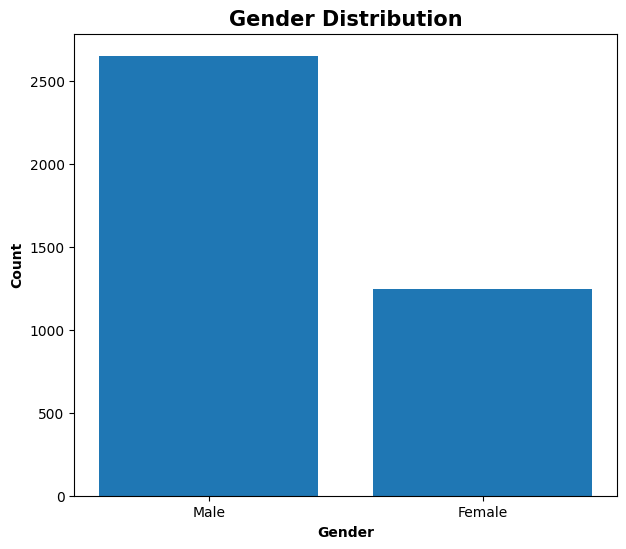

```python
plt.figure(figsize=(7,6))
plt.title("Gender Distribution", fontsize = 15, fontweight = 'bold')
plt.bar(["Male","Female"],df["Gender"].value_counts())
plt.xlabel('Gender',fontweight = 'bold')
plt.ylabel('Count',fontweight = 'bold')
plt.show()
```

==> Making a dataframe - 'age_groups'

```python
df["age_groups"] = np.where(df["Age"] >= 21, "Adult", "Teenager")
print(df["age_groups"].value_counts())
```

```
age_groups
Adult       3688
Teenager     212
Name: count, dtype: int64
```

==> Bar chart distribution for the age groups - 'Teenagers' and 'Adults'

```
Number of teenagers and adult who bought clothes
```

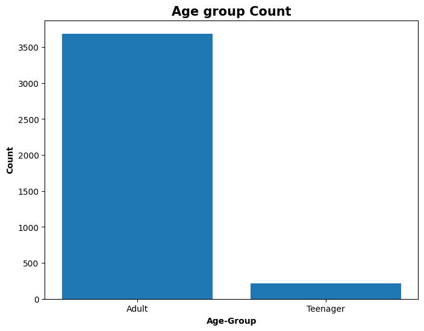

```python
print("\nNumber of teenagers and adult who bought clothes")
plt.figure(figsize=(8, 6))
plt.title("Age group Count", fontsize = 15, fontweight = 'bold')
plt.bar(["Adult", "Teenager"],df["age_groups"].value_counts())
plt.xlabel("Age-Group",fontweight = 'bold')
plt.ylabel("Count",fontweight = 'bold')
plt.show()
```

==> Pie chart for the Top 10 items purchased by males

```
Top 10 Items Purchased by Males
Item Purchased
Pants      123
Jewelry    119
Coat       114
Dress      114
Sweater    114
Scarf      112
Shirt      110
Shorts     109
Jacket     109
Skirt      109
Name: count, dtype: int64
```

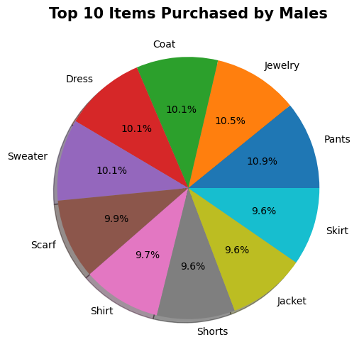

```python
print("\nTop 10 Items Purchased by Males")
males = df[df["Gender"] == "Male"]
top_10_items_purchased = males['Item Purchased'].value_counts()[:10]
print(top_10_items_purchased)
plt.figure(figsize=(10,6))
plt.title("Top 10 Items Purchased by Males", fontsize = 15, fontweight = 'bold')
plt.pie(top_10_items_purchased, autopct='%.1f%%', labels = top_10_items_purchased.index,shadow = True)
plt.show()
```

==> Pie chart for the Top 10 items purchased by females

```
Top 10 Items Purchased by Females
Item Purchased
Blouse        66
Sandals       59
Shirt         59
Socks         58
Handbag       58
Sunglasses    56
Belt          55
Jacket        54
Dress         52
Jewelry       52
Name: count, dtype: int64
```

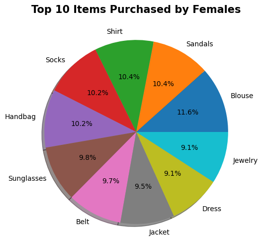

```python
print("\nTop 10 Items Purchased by Females")
females = df[df["Gender"] == "Female"]
top_10_items_purchased = females['Item Purchased'].value_counts()[:10]
print(top_10_items_purchased)
plt.figure(figsize=(10,6))
plt.title("Top 10 Items Purchased by Females", fontsize = 15, fontweight = 'bold')
plt.pie(top_10_items_purchased, autopct='%.1f%%', labels = top_10_items_purchased.index,shadow = True)
plt.show()
```

```python
print("\nDistribution of Purchases in each season")
count_season= df['Season'].value_counts()
print(count_season)
```

```
Distribution of Purchases in each season
Season
Spring    999
Fall      975
Winter    971
Summer    955
Name: count, dtype: int64
```